# Rsession_02_filter_genotypes_and_variants

Mae Goldgraben

28May2018

last updated: Mae Goldgraben, 28May2018

# Notes

Source data includes - ihcap_75_Aug17_vqsr_D0Q100 - annotated vcf which includes 3 more samples for vqsr model.

The hard filters will be applied in the following order:  
gq > 20  
dp < 10x median coverage (median is 106) dp >= 10 reads per sample  
call_rate > 0.5 (as uniform cohort)

Filters consistent with filtering applied to wecare-1K  
- The gq filter >20 is arbitrary; however, consistent with what is done by others  
(e.g. see Carson BMC Bioinformatics. 2014 15:125).

A small number of genotypes is covered by too high or too low sequencing depth to be true.  
These are obvious mistakes, and they have been removed too by choosing an arbitrary threshold  
for max DP of 10x the median sequencing coverage and min DP at 10 reads.

The call rate filter is at 50%, as this is a uniform library dataset.

# start_section

```r
# Time stamp
Sys.time()
```

```
## [1] "2018-05-29 00:34:21 BST"
```

```r
# Clean up
rm(list=ls())

# Load libraries
library(knitr)
library(dplyr)
library(stringr)
library(VennDiagram)
# Folder
setwd("/rds/project/erf33/rds-erf33-medgen/users/mae/IHCAP75_atm_aml/germline_analysis_all_timepts/Rscripts_and_filters")
source_data_folder <- "/rds/project/erf33/rds-erf33-medgen/users/mae/IHCAP75_atm_aml/germline_analysis_all_timepts/Rscripts_and_filters/source_data"
interim_data_folder <- "/rds/project/erf33/rds-erf33-medgen/users/mae/IHCAP75_atm_aml/germline_analysis_all_timepts/Rscripts_and_filters/interim_data"

# Thresholds for genotype quality score & depth
min.gq <- 20
min.dp <- 10
max.dp <- 1060

# Variants call rate threshold
min_call_rate <- 0.5
```

# load_data

```r
load(paste(interim_data_folder, "Rsession_01_read_data_germ.RData", sep="/"))
```

# check_data

```r
dim(gt.mx)
```

```
## [1] 58884     8
```

```r
class(gt.mx)
```

```
## [1] "matrix"
```

```r
gt.mx[1:5,1:5]
```

```
##              IHCAP_010_1 IHCAP_014_1 IHCAP_073_1 IHCAP_75_1A IHCAP_75_1F
## Var000000001           2           2           2           1           1
## Var000000002           2           2           2           2           2
## Var000000003           0           0           0           1           1
## Var000000004           2           2           2           1           1
## Var000000005           2           2           2           1           1
```

```r
dim(gq.mx)
```

```
## [1] 58884     8
```

```r
class(gq.mx)
```

```
## [1] "matrix"
```

```r
gq.mx[1:5,1:5]
```

```
##              IHCAP_010_1 IHCAP_014_1 IHCAP_073_1 IHCAP_75_1A IHCAP_75_1F
## Var000000001          93          15          21          99          90
## Var000000002          72          60          18          36          18
## Var000000003          99          27          27          99          99
## Var000000004          39          12           6          99          50
## Var000000005          78           9          24          99          99
```

```r
dim(dp.mx)
```

```
## [1] 58884     8
```

```r
class(dp.mx)
```

```
## [1] "matrix"
```

```r
dp.mx[1:5,1:5]
```

```
##              IHCAP_010_1 IHCAP_014_1 IHCAP_073_1 IHCAP_75_1A IHCAP_75_1F
## Var000000001          31           5           7          70          33
## Var000000002          24          20           6          12           6
## Var000000003          36           9          11         114          41
## Var000000004          13           4           2          48           9
## Var000000005          26           3           8          58          35
```

```r
dim(vv.df)
```

```
## [1] 58884    68
```

```r
str(vv.df)
```

```
## 'data.frame':    58884 obs. of  68 variables:
##  $ SplitVarID         : Factor w/ 58884 levels "Var000000001",..: 1 2 3 4 5 6 7 8 9 10 ...
##  $ TYPE               : Factor w/ 2 levels "INDEL","SNP": 2 2 2 2 2 2 2 2 2 2 ...
##  $ ID                 : Factor w/ 56646 levels "rs10000804","rs10000924",..: 37846 45960 31675 35975 11065 11059 35976 34750 11063 40446 ...
##  $ CHROM              : Factor w/ 25 levels "1","10","11",..: 1 1 1 1 1 1 1 1 1 1 ...
##  $ POS                : int  876499 877831 881918 887801 889158 889159 889238 892318 894573 897325 ...
##  $ REF                : Factor w/ 620 levels "A","AAAAAAG",..: 1 455 319 1 319 1 319 319 319 319 ...
##  $ ALT                : Factor w/ 499 levels "A","AAAAAAAAGCAC",..: 255 128 1 255 128 128 1 1 1 128 ...
##  $ SYMBOL             : Factor w/ 15065 levels "A1BG","A1CF",..: 11320 11320 8479 8479 8479 8479 8479 8479 8479 6638 ...
##  $ IMPACT             : Factor w/ 4 levels "HIGH","LOW","MODERATE",..: 4 3 3 2 2 2 3 3 4 2 ...
##  $ Consequence        : Factor w/ 60 levels "3_prime_UTR_variant",..: 16 20 20 57 43 43 20 20 16 57 ...
##  $ AS_VQSLOD          : num  14.35 7.04 14.67 5.02 14.63 ...
##  $ FILTER             : Factor w/ 1 level "PASS": 1 1 1 1 1 1 1 1 1 1 ...
##  $ QUAL               : num  2674 3299 2466 2165 4866 ...
##  $ DP                 : int  275 134 301 157 262 262 502 941 418 797 ...
```

[output cut: 54 more lines]

```r
vv.df[1:5,1:5]
```

```
##                SplitVarID TYPE         ID CHROM    POS
## Var000000001 Var000000001  SNP  rs4372192     1 876499
## Var000000002 Var000000002  SNP  rs6672356     1 877831
## Var000000003 Var000000003  SNP rs35471880     1 881918
## Var000000004 Var000000004  SNP  rs3828047     1 887801
## Var000000005 Var000000005  SNP rs13303056     1 889158
```

```r
dim(kgen.df)
```

```
## [1] 58884     9
```

```r
str(kgen.df)
```

```
## 'data.frame':    58884 obs. of  9 variables:
##  $ SplitVarID : Factor w/ 58884 levels "Var000000001",..: 1 2 3 4 5 6 7 8 9 10 ...
##  $ kgen.AC    : int  4573 5008 147 4619 4529 4529 283 NA 3177 4303 ...
##  $ kgen.AN    : int  5008 5008 5008 5008 5008 5008 5008 NA 5008 5008 ...
##  $ kgen.AF    : num  0.9131 1 0.0294 0.9223 0.9044 ...
##  $ kgen.AFR_AF: num  0.8737 1 0.0038 0.9062 0.829 ...
##  $ kgen.AMR_AF: num  0.9207 1 0.0259 0.9193 0.9135 ...
##  $ kgen.EAS_AF: num  0.921 1 0 0.921 0.936 ...
##  $ kgen.EUR_AF: num  0.9503 1 0.0567 0.9523 0.9523 ...
##  $ kgen.SAS_AF: num  0.9151 1 0.0685 0.9172 0.9172 ...
```

```r
kgen.df[1:5,1:5]
```

```
##                SplitVarID kgen.AC kgen.AN  kgen.AF kgen.AFR_AF
## Var000000001 Var000000001    4573    5008 0.913139      0.8737
## Var000000002 Var000000002    5008    5008 1.000000      1.0000
## Var000000003 Var000000003     147    5008 0.029353      0.0038
## Var000000004 Var000000004    4619    5008 0.922324      0.9062
## Var000000005 Var000000005    4529    5008 0.904353      0.8290
```

```r
dim(exac.df)
```

```
## [1] 58884    48
```

```r
str(exac.df)
```

```
## 'data.frame':    58884 obs. of  48 variables:
##  $ SplitVarID             : Factor w/ 58884 levels "Var000000001",..: 1 2 3 4 5 6 7 8 9 10 ...
##  $ exac_non_TCGA.AF       : num  0.92 0.999 0.045 NA 0.927 ...
##  $ exac_non_TCGA.AC       : int  94211 67188 4735 NA 98428 98427 NA 1 85504 NA ...
##  $ exac_non_TCGA.AN       : int  102362 67222 106208 NA 106156 106156 NA 106210 105886 NA ...
##  $ exac_non_TCGA.AC_FEMALE: int  19128 4832 1867 42872 41526 41568 2446 1 33365 41373 ...
##  $ exac_non_TCGA.AN_FEMALE: int  20608 4832 45004 45788 44840 44882 45362 45874 42478 45840 ...
##  $ exac_non_TCGA.AC_MALE  : int  28149 10233 2848 56327 55420 55440 3645 0 48322 54985 ...
##  $ exac_non_TCGA.AN_MALE  : int  30374 10234 59378 60276 59652 59676 60082 60334 57754 60328 ...
##  $ exac_non_TCGA.AC_Adj   : int  47277 15065 4715 99199 96946 97008 6091 1 81687 96358 ...
##  $ exac_non_TCGA.AN_Adj   : int  50982 15066 104382 106064 104492 104558 105444 106208 100232 106168 ...
##  $ exac_non_TCGA.AC_Hom   : int  21867 7532 152 46406 45021 45049 204 0 34649 43934 ...
##  $ exac_non_TCGA.AC_Het   : int  3543 1 4411 6386 6904 6910 5683 1 12389 8489 ...
##  $ exac_non_TCGA.AC_Hemi  : int  NA NA NA NA NA NA NA NA NA NA ...
##  $ exac_non_TCGA.AC_AFR   : int  3358 532 93 8214 7293 7302 188 0 2068 6526 ...
```

[output cut: 34 more lines]

```r
exac.df[1:5,1:5]
```

```
##                SplitVarID exac_non_TCGA.AF exac_non_TCGA.AC
## Var000000001 Var000000001            0.920            94211
## Var000000002 Var000000002            0.999            67188
## Var000000003 Var000000003            0.045             4735
## Var000000004 Var000000004               NA               NA
## Var000000005 Var000000005            0.927            98428
##              exac_non_TCGA.AN exac_non_TCGA.AC_FEMALE
## Var000000001           102362                   19128
## Var000000002            67222                    4832
## Var000000003           106208                    1867
## Var000000004               NA                   42872
## Var000000005           106156                   41526
```

```r
# Check consistence of rownames
sum(rownames(gt.mx) != rownames(gq.mx))
```

```
## [1] 0
```

```r
sum(rownames(gt.mx) != rownames(dp.mx))
```

```
## [1] 0
```

```r
sum(rownames(gt.mx) != rownames(vv.df))
```

```
## [1] 0
```

```r
sum(rownames(gt.mx) != rownames(kgen.df))
```

```
## [1] 0
```

```r
sum(rownames(gt.mx) != rownames(exac.df))
```

```
## [1] 0
```

```r
# Check consistence of colnames
sum(colnames(gt.mx) != colnames(gq.mx))
```

```
## [1] 0
```

```r
sum(colnames(gt.mx) != colnames(dp.mx))
```

```
## [1] 0
```

# explore_data_before_filtering

Calculate genotype NA rates Histogram of call rates per variant, gq and dp in non-NA genotypes

```r
# Fraction of NA genotypes before filtering
sum(is.na(gt.mx))/(nrow(gt.mx)*ncol(gt.mx)) # ~1.4%;
```

```
## [1] 0.01388747
```

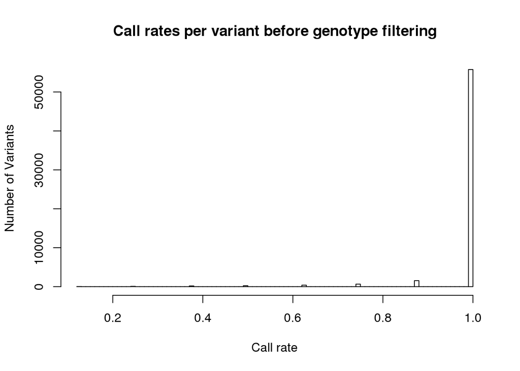

```r
# Was 4% for wecare

# Call rates per variant before filtering
x <- ncol(gt.mx)
y <- apply(gt.mx,1,function(z){1-sum(is.na(z))/x})
hist(y, breaks=100,xlab="Call rate", ylab="Number of Variants",
     main="Call rates per variant before genotype filtering")
```

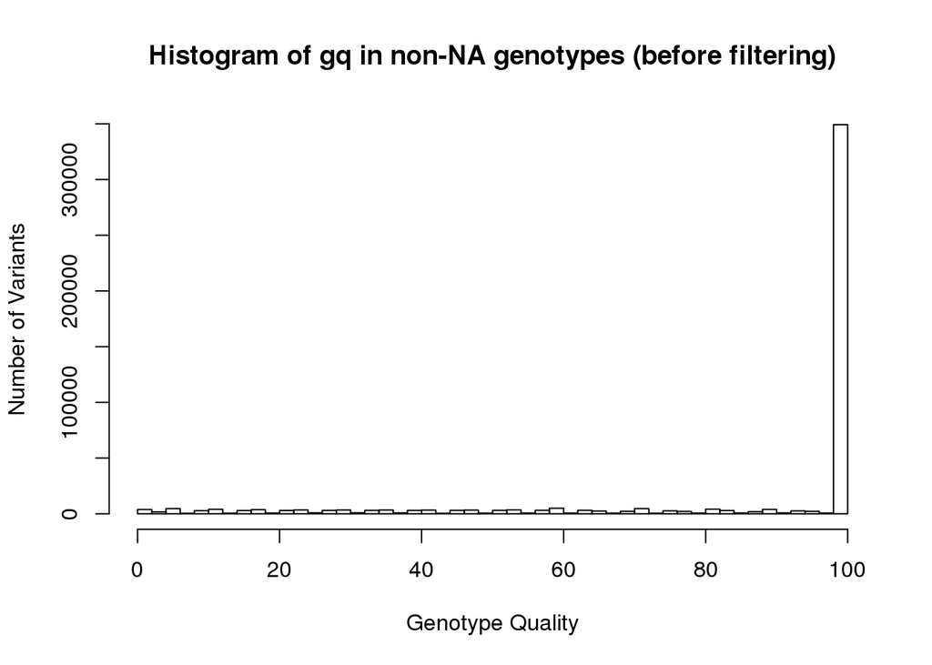

```r
# Histogram of gq before filtering (when gt is not NA !)
hist(gq.mx[!is.na(gt.mx)], breaks=50, xlab="Genotype Quality", ylab="Number of Variants",
     main="Histogram of gq in non-NA genotypes (before filtering)")
```

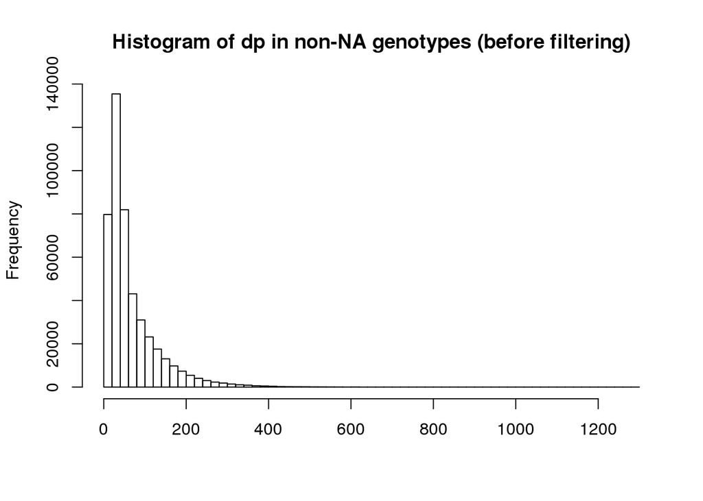

```r
# Histogram of dp before filtering (when gt is not NA !)
hist(dp.mx[!is.na(gt.mx)], breaks=50, xlab=NULL, main="Histogram of dp in non-NA genotypes (before filtering)")
```

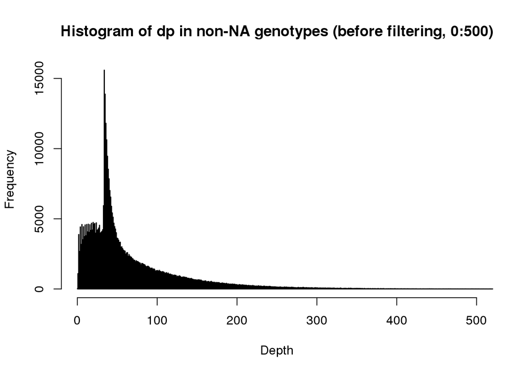

```r
hist(dp.mx[!is.na(gt.mx)], breaks=2500, xlab = "Depth", xlim=c(0,500), main="Histogram of dp in non-NA genotypes (before filtering, 0:500)")
```

```r
# Clean-up
rm(x,y)
```

# filter_out_low_gq

Put NA to genotypes where gq < 20 : removes ~5% of non-NA genotypes

```r
# num of genotypes that are NA and number to be removed from gt.mx
sum(gq.mx < min.gq, na.rm=TRUE) # 24,861
```

```
## [1] 24861
```

```r
sum(gq.mx[!is.na(gt.mx)] < min.gq, na.rm=TRUE) # 24,861
```

```
## [1] 24861
```

```r
# Fraction of genotypes to be removed
sum(!is.na(gt.mx)) # 464,530
```

```
## [1] 464530
```

```r
sum(gq.mx < min.gq, na.rm=TRUE)/sum(!is.na(gq.mx)) # ~5% of gq.mx ; wecare was 8%
```

```
## [1] 0.05353578
```

```r
sum(gq.mx[!is.na(gt.mx)] < min.gq, na.rm=TRUE) / sum(!is.na(gt.mx)) # ~5% of gt.mx
```

```
## [1] 0.05351861
```

```r
# Apply filter (to gt only !)
NA -> gt.mx[ gq.mx < min.gq ]

# Clean up
rm(min.gq)
```

# explore_data_after_gq_filtering

Calculate genotype NA rates Histogram of call rates per variant, gq and dp in non-NA genotypes

```r
dim(gt.mx)
```

```
## [1] 58884     8
```

```r
# Fraction of NA genotypes after gq filtering
sum(is.na(gt.mx))/(dim(gt.mx)[1]*dim(gt.mx)[2]) # ~6%
```

```
## [1] 0.06666285
```

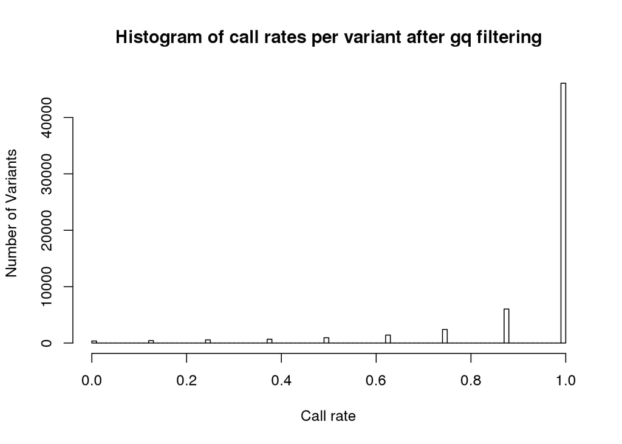

```r
# Call rates per variant after gq filtering
x <- ncol(gt.mx)
y <- apply(gt.mx, 1, function(z){1-sum(is.na(z))/x})
hist(y, breaks=100, xlab="Call rate", ylab="Number of Variants",
     main="Histogram of call rates per variant after gq filtering")
```

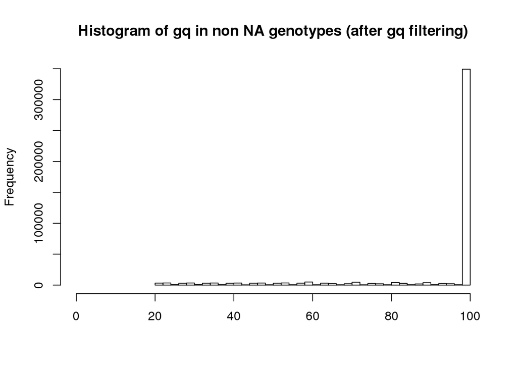

```r
# Histogram of gq after gq filtering (when gt is not NA !)
hist(gq.mx[!is.na(gt.mx)], xlim=c(0,100), xlab=NULL, breaks=50, main="Histogram of gq in non NA genotypes (after gq filtering)")
```

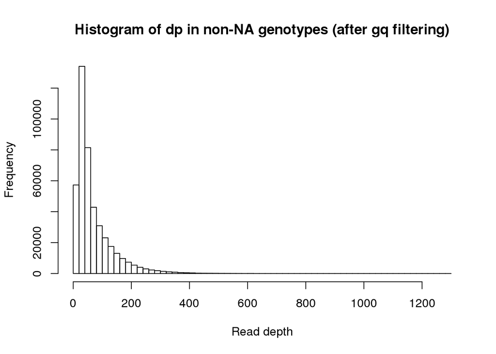

```r
# Histogram of dp after gt filtering (when gt is not NA !)
hist(dp.mx[!is.na(gt.mx)], breaks=50, xlab="Read depth", main="Histogram of dp in non-NA genotypes (after gq filtering)")
```

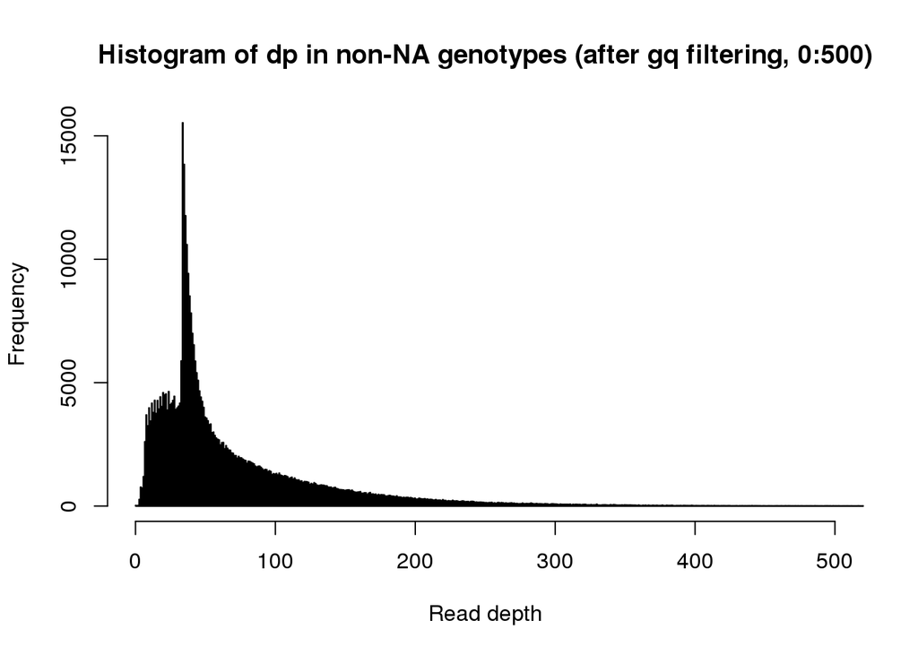

```r
hist(dp.mx[!is.na(gt.mx)], xlim=c(0,500), xlab="Read depth", breaks=2500, main="Histogram of dp in non-NA genotypes (after gq filtering, 0:500)")
```

```r
# Clean up
rm(x, y)
```

# filter_out_high_dp

put NA to genotypes where dp > 10x median coverage (i.e. 1060) : removes ~<1% of non-NA genotypes

```r
# Calculate number of max DP variants to be removed from gt.mx
dp_max.mx <- as.matrix(dp.mx > max.dp)
sum(dp_max.mx, na.rm=TRUE) # 1
```

```
## [1] 1
```

```r
sum(is.na(dp_max.mx)) # 2
```

```
## [1] 2
```

```r
sum(dp_max.mx[!is.na(gt.mx)], na.rm=TRUE) # 1
```

```
## [1] 1
```

```r
# Fraction of genotypes to be removed (approx)
sum(!is.na(gt.mx)) # 439,669
```

```
## [1] 439669
```

```r
sum(dp_max.mx[!is.na(gt.mx)], na.rm=TRUE) / sum(!is.na(gt.mx)) # 0.000002; <1%
```

```
## [1] 2.274438e-06
```

```r
# Apply filter (to gt only!; can only run on matrices)
NA -> gt.mx[dp_max.mx]
sum(!is.na(gt.mx)) # 439,668
```

```
## [1] 439668
```

```r
# Clean up
rm(dp_max.mx, max.dp)
```

# explore_data_after_gq_Hdp_filtering

Calculate genotype NA rates Histogram of call rates per variant, gq and dp

```r
dim(gt.mx)
```

```
## [1] 58884     8
```

```r
# Fraction of NA genotypes after gq + Hdp filtering
sum(is.na(gt.mx))/(dim(gt.mx)[1]*dim(gt.mx)[2]) # 6.67%
```

```
## [1] 0.06666497
```

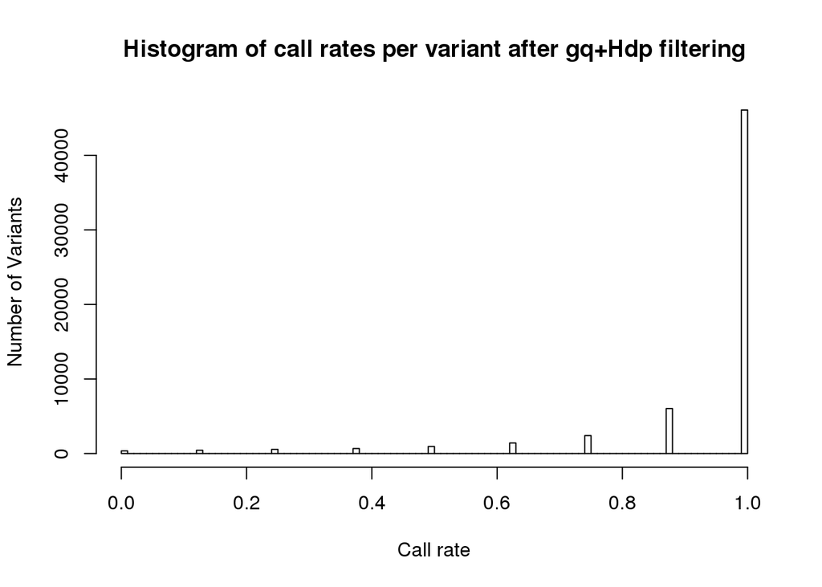

```r
# Call rates per variant after gq + Hdp filtering
x <- ncol(gt.mx)
y <- apply(gt.mx, 1, function(z){1-sum(is.na(z))/x})
hist(y, breaks=100, xlab="Call rate", ylab="Number of Variants", main="Histogram of call rates per variant after gq+Hdp filtering")
```

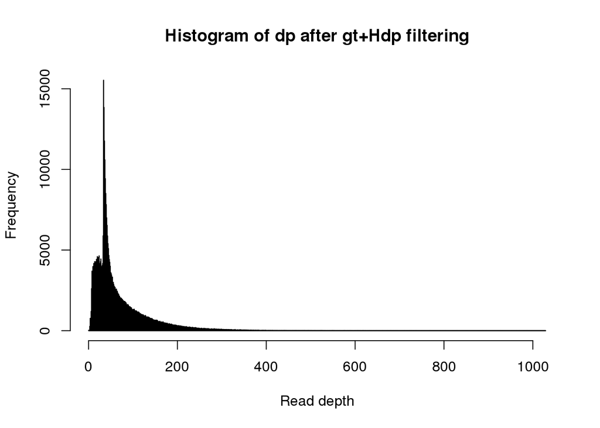

```r
# Histogram of dp after gt+Hdp filtering (when gt is not NA !)
hist(dp.mx[!is.na(gt.mx)], xlab="Read depth", breaks=2500, main="Histogram of dp after gt+Hdp filtering")
```

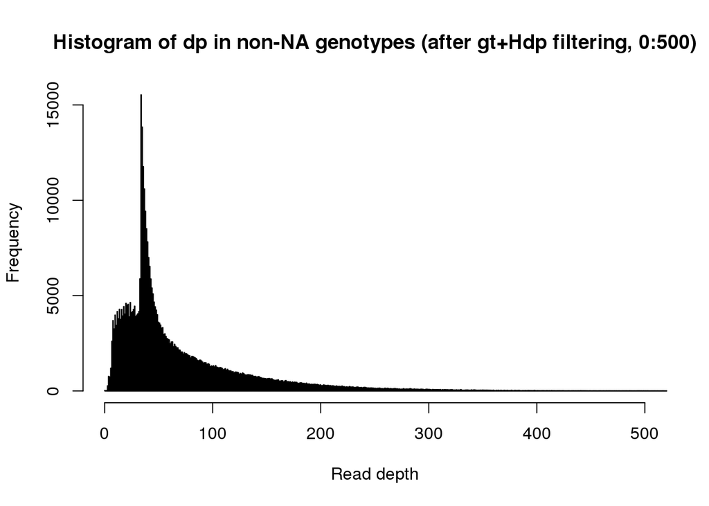

```r
hist(dp.mx[!is.na(gt.mx)], xlim=c(0,500), xlab="Read depth", breaks=2500, main="Histogram of dp in non-NA genotypes (after gt+Hdp filtering, 0:500)")
```

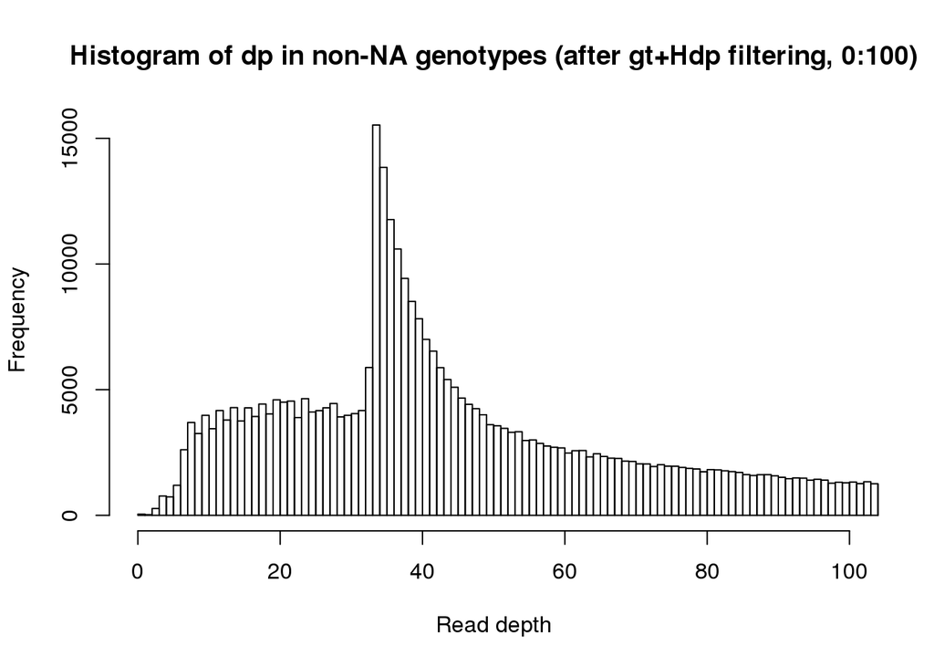

```r
hist(dp.mx[!is.na(gt.mx)], xlim=c(0,100), xlab="Read depth", breaks=1000, main="Histogram of dp in non-NA genotypes (after gt+Hdp filtering, 0:100)")
```

```r
# Clean up
rm(x, y)
```

# filter_out_low_dp

put NA to genotypes where dp < 10 per sample, removes 8% of variants

```r
# Num of genotypes that are NA and number to be removed from gt.mx
sum(dp.mx < min.dp, na.rm=TRUE) # 37,899
```

```
## [1] 37899
```

```r
sum(dp.mx[!is.na(gt.mx)] < min.dp, na.rm=TRUE) # 12,598
```

```
## [1] 12598
```

```r
# Fraction of genotypes to be removed (approx)
sum(!is.na(gt.mx)) # 439,668
```

```
## [1] 439668
```

```r
sum(dp.mx < min.dp, na.rm=TRUE)/sum(!is.na(dp.mx)) # ~8% of dp.mx
```

```
## [1] 0.08045301
```

```r
sum(dp.mx[!is.na(gt.mx)] < min.dp, na.rm=TRUE) / sum(!is.na(gt.mx)) # 0.028; <3% of gt.mx
```

```
## [1] 0.02865344
```

```r
# Apply filter (to gt only!; can only run on matrices)
NA -> gt.mx[ dp.mx < min.dp ]
sum(!is.na(gt.mx)) # 427,070
```

```
## [1] 427070
```

```r
# Clean up
rm(min.dp)
```

# explore_data_after_gq_Hdp_Ldp_filtering

Calculate genotype NA rates Histogram of call rates per variant and dp

```r
dim(gt.mx)
```

```
## [1] 58884     8
```

```r
# Fraction of NA genotypes after gq + Hdp + Ldp filtering
sum(is.na(gt.mx))/(dim(gt.mx)[1]*dim(gt.mx)[2]) # 9%
```

```
## [1] 0.09340823
```

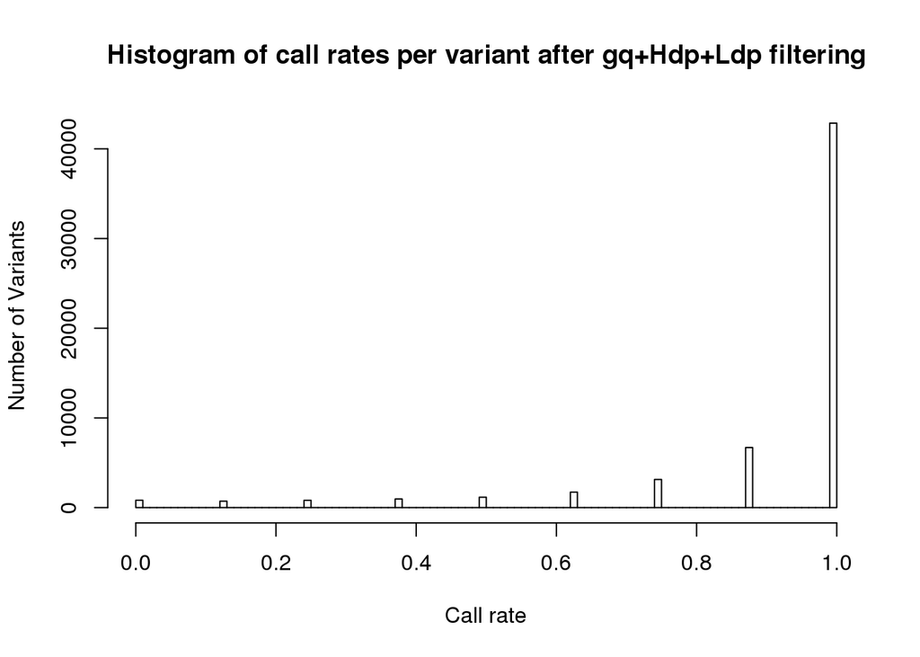

```r
# Call rates per variant after gq + Hdp + Ldp filtering
x <- ncol(gt.mx)
y <- apply(gt.mx, 1, function(z){1-sum(is.na(z))/x})
hist(y, breaks=100, xlab="Call rate", ylab="Number of Variants",
     main="Histogram of call rates per variant after gq+Hdp+Ldp filtering")
```

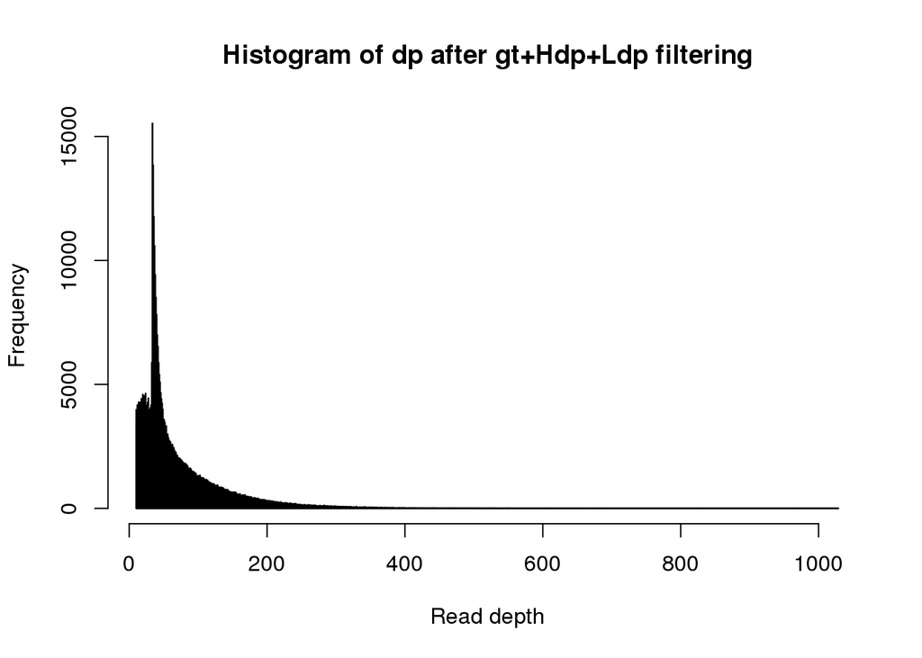

```r
# Histogram of dp after gt+Hdp+Ldp filtering (when gt is not NA !)
hist(dp.mx[!is.na(gt.mx)], xlab="Read depth", breaks=2500, main="Histogram of dp after gt+Hdp+Ldp filtering")
```

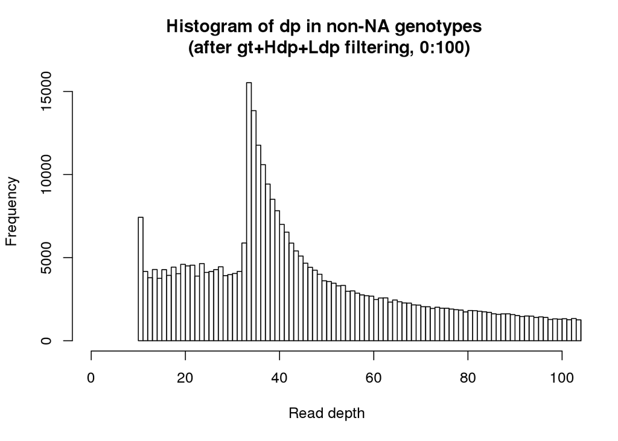

```r
hist(dp.mx[!is.na(gt.mx)], xlim=c(0,100), xlab="Read depth", breaks=1000,
     main="Histogram of dp in non-NA genotypes \n (after gt+Hdp+Ldp filtering, 0:100)")
```

```r
# Clean up
rm(x, y)
```

# filter_variants_by_cohort_call_rate

Remove variants with call rate < 50%

```r
# Look at all non-NAs in gt.mx
dim(gt.mx) # 58,884 x 8 = 471,072
```

```
## [1] 58884     8
```

```r
sum(!is.na(gt.mx))/(nrow(gt.mx)*ncol(gt.mx)) # 90% of in gt.mx variants are good
```

```
## [1] 0.9065918
```

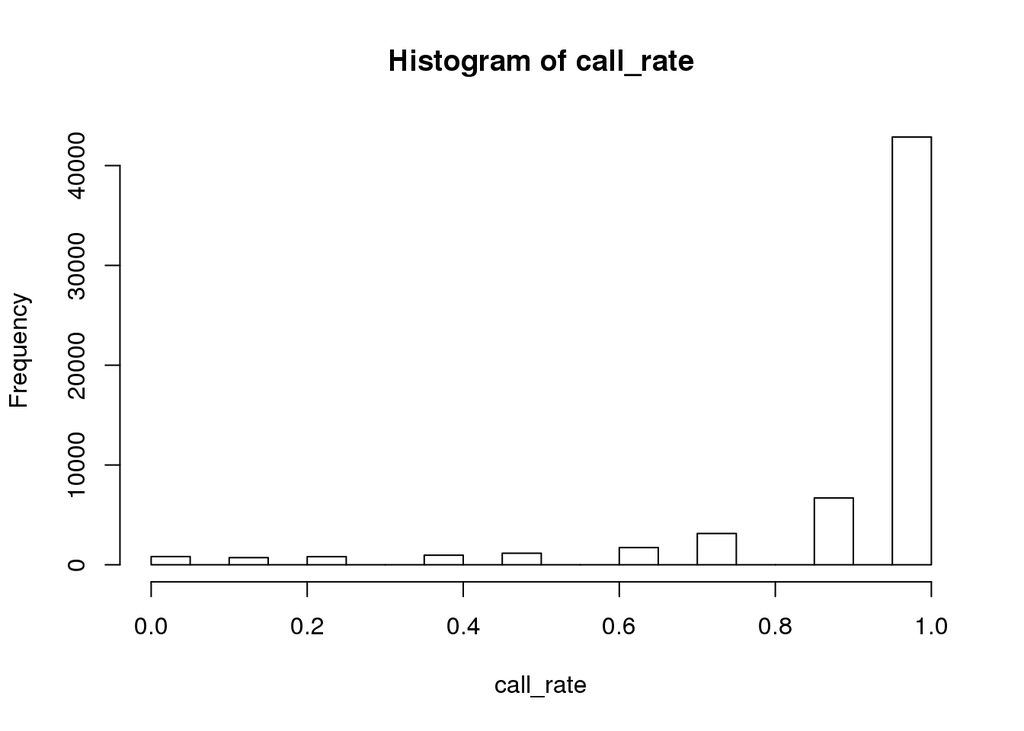

```r
# Calculate the "good call rate variants" & estimate the proportion of variants to be retained
call_rate.udf <- function(x){sum(!is.na(x))/length(x)}

call_rate <- apply(gt.mx, 1, call_rate.udf)
hist(call_rate)
```

```r
good_variants <- call_rate >= min_call_rate
summary(good_variants) # 55,579
```

```
##    Mode   FALSE    TRUE    NA's
## logical    3305   55579       0
```

```r
sum(good_variants)/nrow(gt.mx) # 94% variants retained
```

```
## [1] 0.9438727
```

```r
# Apply call rate filter to gt.mx
sum(is.na(gt.mx)) # 44,002
```

```
## [1] 44002
```

```r
NA -> gt.mx[!good_variants,]
sum(is.na(gt.mx)) # 49,210
```

```
## [1] 49210
```

```r
dim(gt.mx) # 58,884 x 8
```

```
## [1] 58884     8
```

```r
# Clean-up
rm(min_call_rate, call_rate.udf, call_rate, good_variants)
```

# cleanup_good_call_rate_gt_mxs

Remove poor quality variants across all subsets, clean up vv/kgen/exac files

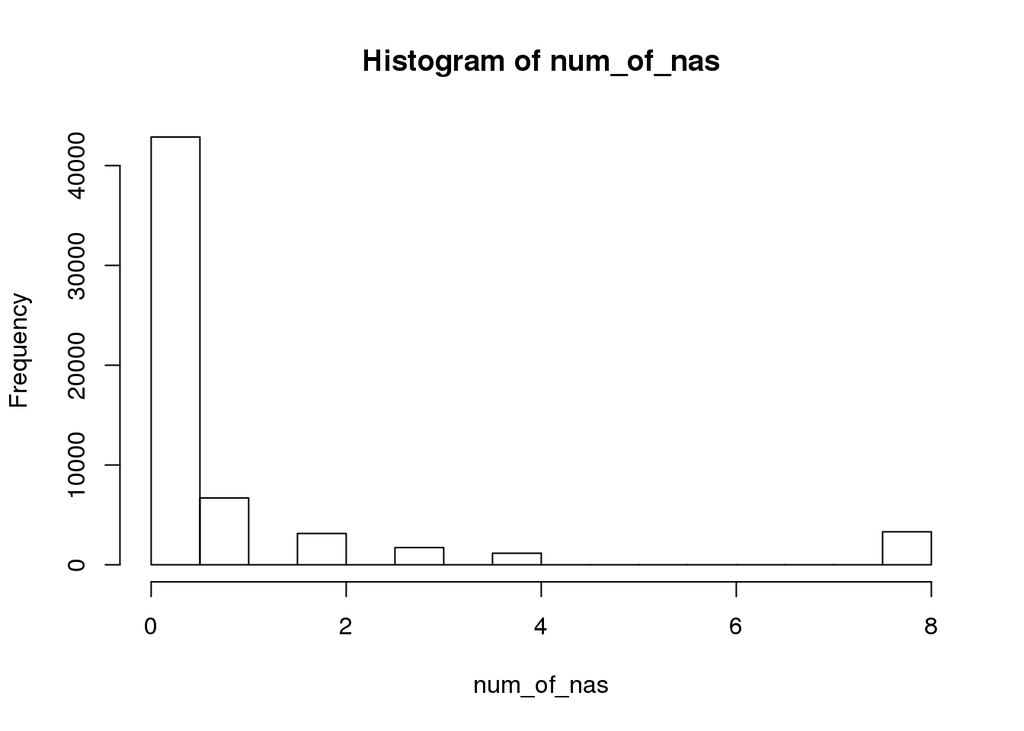

```r
# Clean up gt matrix for very poor variants
count_nas.udf <- function(x){sum(is.na(x))}

num_of_nas <- apply(gt.mx, 1, count_nas.udf)
hist(num_of_nas)
```

```r
very_poor_variants <- num_of_nas == ncol(gt.mx)
summary(very_poor_variants) # 3,305
```

```
##    Mode   FALSE    TRUE    NA's
## logical   55579    3305       0
```

```r
dim(gt.mx) # 58,884 x 8
```

```
## [1] 58884     8
```

```r
cleaned_gt.mx <- gt.mx[!very_poor_variants,]
dim(cleaned_gt.mx) # 55,579 x 8
```

```
## [1] 55579     8
```

```r
# ---- Clean up vv.df, exac.df and kgen.df ---- #

cleaned_variants <- rownames(cleaned_gt.mx)

cleaned_vv.df <- vv.df[cleaned_variants, ]
dim(cleaned_vv.df) # 55,579 x 68
```

```
## [1] 55579    68
```

```r
cleaned_kgen.df <- kgen.df[cleaned_variants, ]
dim(cleaned_kgen.df) # 55,579 x 9
```

```
## [1] 55579     9
```

```r
cleaned_exac.df <- exac.df[cleaned_variants, ]
dim(cleaned_exac.df) # 55,579 x 48
```

```
## [1] 55579    48
```

```r
# Clean-up
rm(count_nas.udf, num_of_nas, very_poor_variants, cleaned_variants)
```

# check_remaining_files_and_remove_unnecessary_data

```r
# Check consistency of rownames
sum(rownames(cleaned_gt.mx) != rownames(cleaned_vv.df))
```

```
## [1] 0
```

```r
sum(rownames(cleaned_gt.mx) != rownames(cleaned_kgen.df))
```

```
## [1] 0
```

```r
sum(rownames(cleaned_gt.mx) != rownames(cleaned_exac.df))
```

```
## [1] 0
```

```r
# Clean-up

rm(gt.mx, gq.mx, dp.mx, vv.df, kgen.df, exac.df)
```

# save_data

```r
save.image(paste(interim_data_folder, "Rsession_02_filter_genotypes_and_variants_germ.RData", sep="/"))
```

# final_section

```r
ls()
```

```
## [1] "cleaned_exac.df"     "cleaned_gt.mx"       "cleaned_kgen.df"
## [4] "cleaned_vv.df"       "interim_data_folder" "source_data_folder"
```

```r
Sys.time()
```

```
## [1] "2018-05-29 00:34:32 BST"
```